# RT-DC Data

Setup

Load and clean data

```r
source("load_rtdc_3.R")
XL_PATH <- file.path(PROJ_DIR, "rt-dc_eb_2.xls")
rtdc_tall <- load_rtdc_3(XL_PATH)
```

We evaluate whether data is a better fit to normal or log-normal. First view without taking the log:

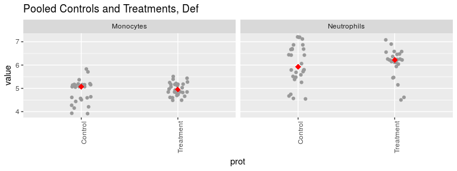

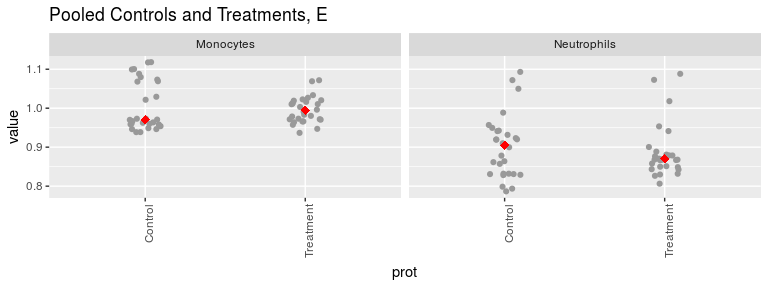

Deformation looks relatively normal but E is skewed right (towards the top of the chart).

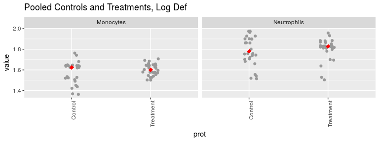

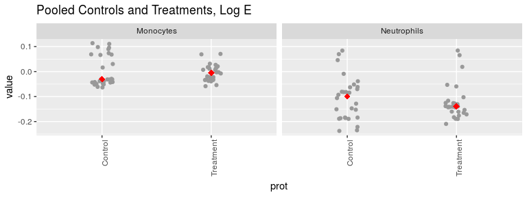

This does not seem to have changed much so data will be treated as normal for this initial study, however it appears to have some clustering.

Explore summary stats of Young’s modulus and deformation, keeping each trial separate (in principle the controls can be pooled and will be below). There are many outliers so the effect is clearest using a robust statistic (median) for the central tendency (red dot):

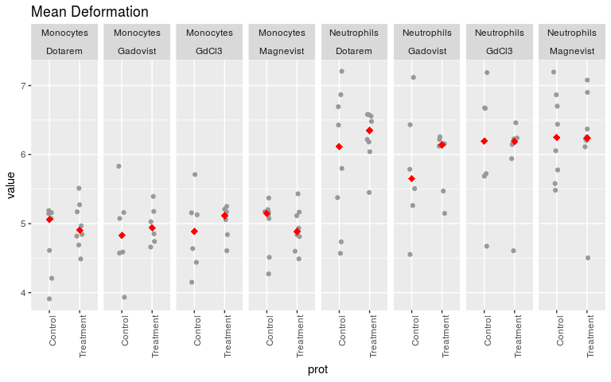

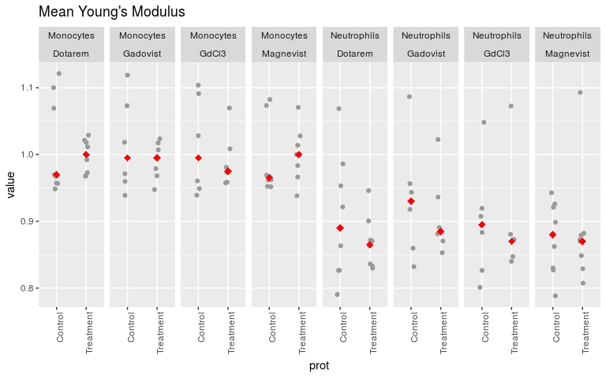

Exploring ranges with all controls pooled:

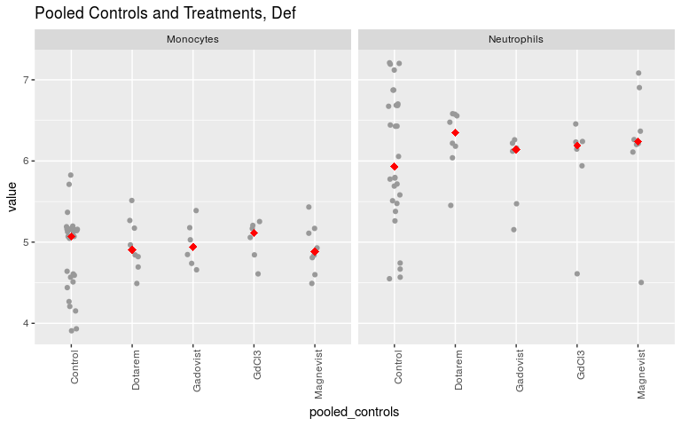

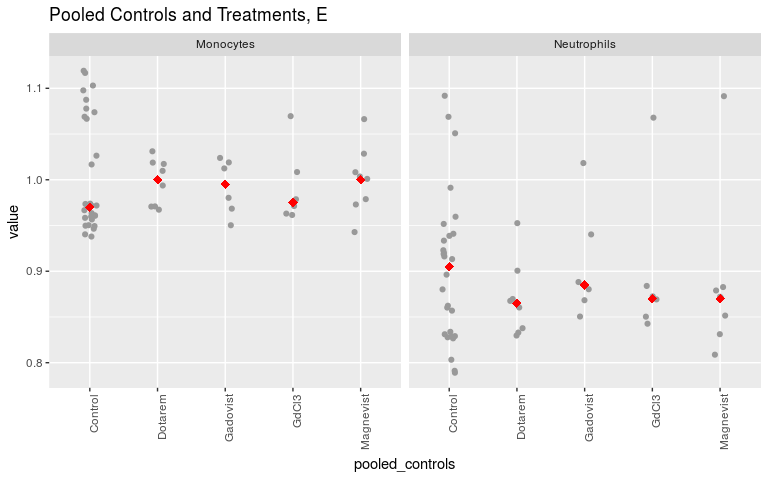

Def and E continue to be “mirror images” of each other which is a good reality check that the process is physical. Visually the effects seem relatively clear however the distribution of the controls is highly dispersed, and some contrast agents sets contain one strong outlier.

For a first statistical analysis, to handle the large impact of outliers, the data were regressed against a linear model with a Student’s t distribution. JAGS code for the model was:

```r
student_t_model <- "
model {
    for (i in 1:length(y)) {
        y[i] ~ dt(mu[i], tau, k)
        mu[i] <- beta[cont_ag[i]]
    }

    for (k in 1:n_cont_ag) {
        beta[k] ~ dnorm(mu_ag, tau_ag)
    }

    sig ~ dunif(0.001, 1000)
    tau <- 1 / sig^2
    k ~ dunif(0.001, 10)

    mu_ag ~ dnorm(0, 1 / 10000)
    sig_ag ~ dunif(0.001, 1000)
    tau_ag <- 1 / sig_ag^2
}
"
```

As both Young’s modulus and deformation behave similarly we use the deformation for this first analysis. As we are not sure if the two cell types are affected similarly by the agents, we analyze Neutrophils alone first. Cleaning and subsetting the data:

```r
neutro_subset <- subset(rtdc_tall, measurement == "mean_def" & cell_type == "Neutrophils")
jags_dataset <- list(
    y = neutro_subset$value,
    cont_ag = neutro_subset$pooled_controls,
    n_cont_ag = length(levels(neutro_subset$pooled_controls))
)
jags_model <- jags.model(file = textConnection(student_t_model), data = jags_dataset, n.chains = 3)
```

[output not shown]

```r
update(jags_model, 1e3)
```

[output not shown]

```r
sim <- coda.samples(model=jags_model, variable.names = c("beta", "tau", "k", "mu_ag", "tau_ag"), n.iter = 5e3)
```

[output not shown]

```r
gelman <- gelman.diag(sim)
csim <- as.mcmc(do.call(rbind, sim))
```

Chains look overall good, except tau_ag looks sparse:

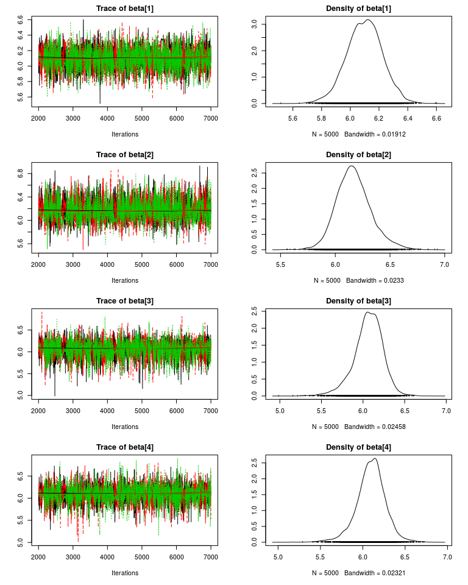

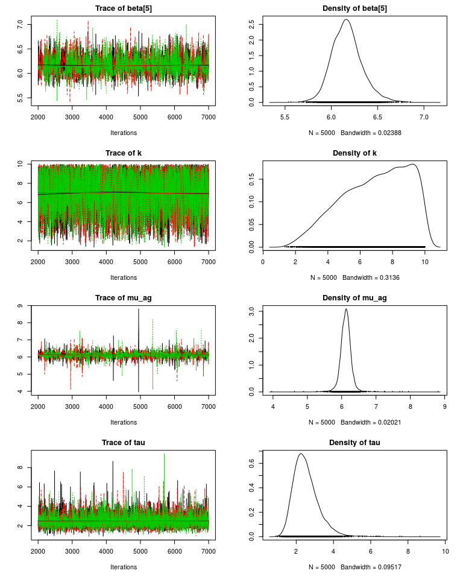

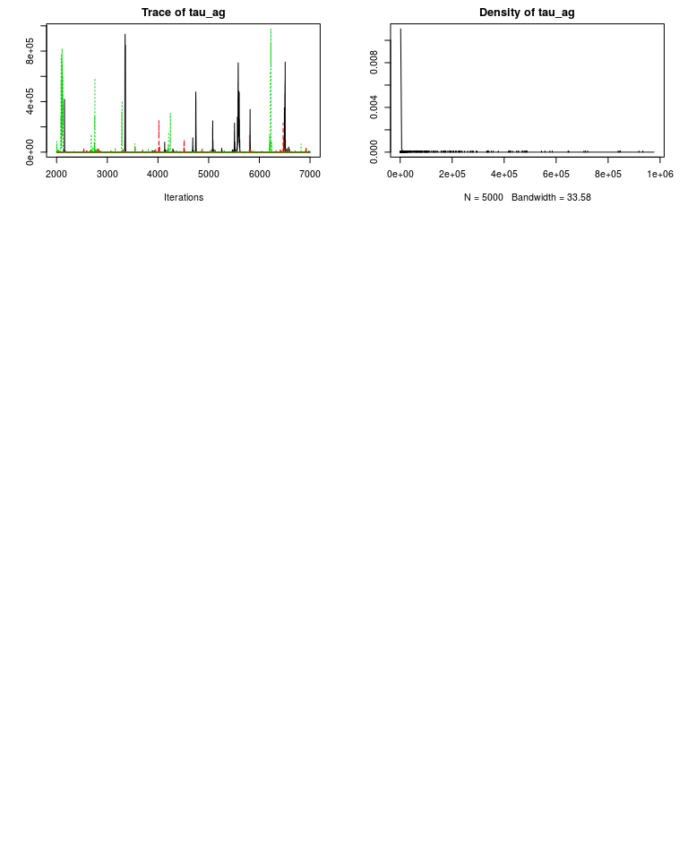

```r
plot(sim)
```

Gelman diagnostic looks good besides tau_ag:

```r
print(gelman)
```

```
Potential scale reduction factors:

        Point est. Upper C.I.
beta[1]       1.00       1.00
beta[2]       1.00       1.00
beta[3]       1.00       1.00
beta[4]       1.00       1.00
beta[5]       1.00       1.00
k             1.00       1.00
mu_ag         1.00       1.00
tau           1.00       1.00
tau_ag        1.12       1.16

Multivariate psrf

1.01
```

Plot densities and contrasts:

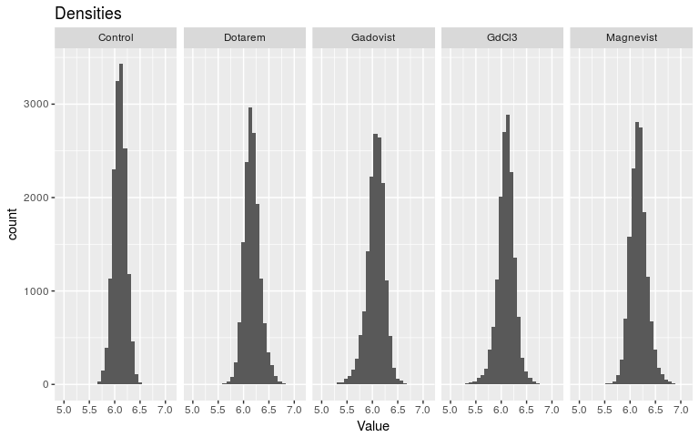

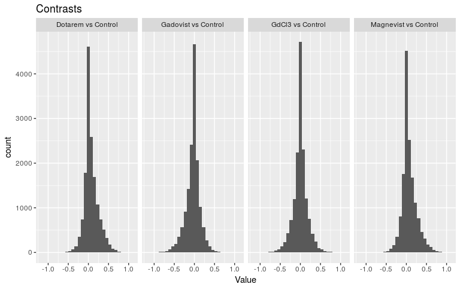

```r
print("Densities:")
print(hdi(densities))
print("Contrasts:")
print(hdi(contrasts))
```

[output not shown]

TO DO: - It is surprising that the HDI of the control is comparable to (or less than) the HDIs of some of the contrast agents. It should be much wider, and presumably this is a shrinkage effect, but needs to be investigated further. - tau_ag is not converging, should I rethink this aspect of the model (assuming this is a model worth keeping?)